# Creating Dynamic Presentations

03/02/2025

## Creating slide presentations using *RStudio*

*RStudio* has developed two related file formats designed for creating slide presentations: the *R Markdown* format (files with extension *.Rmd*) and the *RPresentations* format (files with extension *.Rpres*). Both formats use the *R Markdown* flavor of the *markdown* markup language, but differ in the way they are rendered into slide presentations.

*R Markdown* files can be rendered into either one of two interactive *html* slide presentations: **ioslides** or *slidy*, or into non-interactive *pdf* slide presentations. *R Markdown* documents can also be rendered into standard *pdf* or *html* documents that aren’t slides.

Both **ioslides** and *slidy* slide presentations can have embedded in them interactive plots, like *shiny*, *dygraphs*, and *plotly*. **ioslides** and *slidy* presentations with embedded *dygraphs* or *plotly* interactive plots can be produced as single, standalone *html* files, which makes them easy to share. But slide presentations with embedded *shiny* interactive plots contain a live *R* session, so they can’t be saved as a single file.

*RStudio* offers several tutorials about writing presentations in *R Markdown*:

Introduction to *R Markdown*: [*R Markdown*](http://rmarkdown.RStudio.com/)

Authoring *R Markdown* Presentations: [Authoring *R Markdown* Presentations](https://support.RStudio.com/hc/en-us/articles/200486468-Authoring-R-Presentations)

## The *RPresentations* format

The *RPresentations* document format allows embedding *R* chunks, and static visualizations of data (plots and charts), but not *shiny* applications. *RPresentations* can be saved as standalone *html* files. One advantage of *RPresentations* is that they allow for creating slides with two columns. The *RPresentations* document format is now deprecated in favor of the pure *R Markdown* format.

Introduction to RPresentations: [RPresentations](https://support.RStudio.com/hc/en-us/sections/200130218-R-Presentations)

## Interactive **ioslides** Slide Presentations

**ioslides** is an interactive *html* slide presentation format developed by *RStudio*. This presentation is an interactive **ioslides** presentation written in *R Markdown*.

*RStudio* offers tutorials about writing presentations in *R Markdown*. Introduction to *R Markdown*: [*R Markdown*](http://rmarkdown.RStudio.com/)

Authoring *R Markdown* Presentations: [Authoring *R Markdown* Presentations](https://support.RStudio.com/hc/en-us/articles/200486468-Authoring-R-Presentations)

*RStudio* offers several tutorials about writing interactive presentations in *R Markdown*. Introduction to **ioslides**: [*R Markdown*](http://rmarkdown.RStudio.com/*ioslides*_presentation_format.html)

This link offers a good introduction to *R Markdown* slide presentations, explaining the difference between **ioslides** presentations versus *slidy*: [*R Markdown* slide presentation formats: **ioslides** versus *slidy*](http://data-analytics.net/cep/Schedule_files/presentations_demo.html)

## **ioslides** Slide Presentations

### Rendered from *R Markdown* Documents

**ioslides** slide presentations are much better than powerpoint because they allow embedding interactive plots and other interactive elements encoded in *JavaScript*.

This is an **ioslides** slide presentation rendered from an *R Markdown* document. *R Markdown* is a simple markup language derived from *markdown*. *R Markdown* documents can be rendered into *HTML*, *pdf*, and *MS Word* documents. *R Markdown* documents have the file extension `.Rmd`.

For more details on using *markdown* see [this *markdown* page](https://daringfireball.net/projects/markdown/), and for *R Markdown* see [this *R Markdown* page](http://rmarkdown.rstudio.com).

*R Markdown* documents can be customized by directly using *HTML* code inside the `.Rmd` file.

*R Markdown* files are rendered into slides and *pdf* documents using the [*package knitr*](https://yihui.name/knitr/).

You can render (compile) an *R Markdown* file by clicking on the *knit* button in *RStudio*. This creates an output document in the same directory as the *R Markdown* file, and also displays the output document.

## How to include *R* code chunks

*R Markdown* has additional features compared to *markdown*, like the ability to combine *R* code chunks with text.

*R* code chunks can be embedded in *R Markdown* documents, and they are automatically executed and their output is embedded in the output document.

The behavior of *R* code chunks can be controlled by using [code chunk options](https://yihui.name/knitr/options/).

```r
> head(mtcars)
##                    mpg cyl disp  hp drat   wt qsec vs am gear carb
## Mazda RX4         21.0   6  160 110 3.90 2.62 16.5  0  1    4    4
## Mazda RX4 Wag     21.0   6  160 110 3.90 2.88 17.0  0  1    4    4
## Datsun 710        22.8   4  108  93 3.85 2.32 18.6  1  1    4    1
## Hornet 4 Drive    21.4   6  258 110 3.08 3.21 19.4  1  0    3    1
## Hornet Sportabout 18.7   8  360 175 3.15 3.44 17.0  0  0    3    2
## Valiant           18.1   6  225 105 2.76 3.46 20.2  1  0    3    1
```

## Two-column Layout Using *CSS* Code

The formatting of *R Markdown* documents can be controlled using *CSS* code stored in a separate file. The file with *CSS* code should be either in the same directory as the *R Markdown* file, or in a sub-directory.

Below is an example of two-column layout using *CSS* code.  
The location of the break between columns is specified by the *CSS* style code in the file slides.css.  
The left column is 40%, and the right is 60% of the page width.

The left column contains *R* code that returns the summary of the *cars* data frame:

```r
> summary(cars)
```

The right column contains the output of the *R* code in the left column:

```
##      speed           dist
##  Min.   : 4.0   Min.   :  2
##  1st Qu.:12.0   1st Qu.: 26
##  Median :15.0   Median : 36
##  Mean   :15.4   Mean   : 43
##  3rd Qu.:19.0   3rd Qu.: 56
##  Max.   :25.0   Max.   :120
```

## Slide with an Interactive *dygraphs* Plot

```r
> library(dygraphs, quietly=TRUE)
> library(lubridate, quietly=TRUE)
> xtsv <- log(zoo::coredata(EuStockMarkets[, "DAX"]))
> datev <- date_decimal(zoo::index(EuStockMarkets))
> xtsv <- xts::xts(xtsv, order.by=datev)
> dygraph(xtsv, main = "DAX Index (log)") %>%
+   dyRangeSelector()
```

[interactive chart not shown]

## How to Include Images

Image files can be loaded and displayed by using the following *markdown* syntax:  
`![animated_gif](image/chi_squared.gif)`

The image file should be either in the same directory as the *R Markdown* file, or in a sub-directory.

## Images in Two-column Layout Using *CSS* Code

Image files can be included in two different ways. First, directly by using *markdown* syntax for external links, or by using the function `include_graphics()` in an *R* code chunk.

The image file should be either in the same directory as the *R Markdown* file, or in a sub-directory.

Hello World!  
Creating *R* Presentations isn’t difficult at all!

[figure not shown]

R is fun!

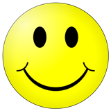

## Plots in Two-column Layout Using *CSS* Code

The Normal probability density function is given by: \[ P(x) = \frac{e^{-(x-\mu)^2/2\sigma^2}}{\sigma\sqrt{2 \pi}} \] Code for plotting the Normal probability density function:

```r
> # Plot a Normal probability distribution
> curve(expr=dnorm(x, sd=1.5), type="l", xlim=c(-5, 5),
+       xlab="", ylab="", lwd=2, col="blue",
+       main="Normal Density Function")
> # Draw shaded area
> xvar <- seq(-5, 5, length=100)
> yvar <- dnorm(xvar, mean=0.0, sd=1.5)
> startd <- 2; endd <- 3
> subv <- ((xvar >= startd) & (xvar <= endd))
> polygon(c(startd, xvar[subv], endd),
+         c(-1, yvar[subv], -1), col="red")
```

Plot of Normal probability density function:

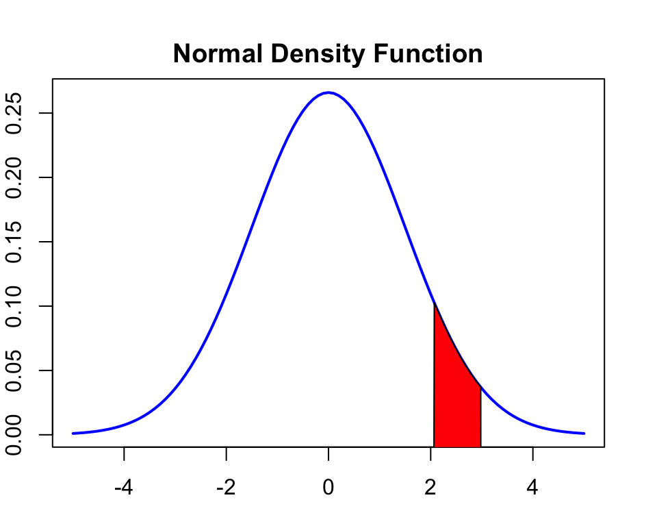

## Slide with *HTML Widget*

Below is a network graph created using the *D3.js JavaScript* library embedded as an *HTML widget*.  
You can select and drag the nodes of the *widget* using your mouse.

```r
> library(networkD3, quietly=TRUE)
> data(MisLinks, MisNodes)
> forceNetwork(Links=MisLinks, Nodes=MisNodes,
+   Source="source", Target="target", Value="value",
+   NodeID="name", Group="group", opacity=0.8)
```

[interactive chart not shown]

## Slide with Incremental Bullets

Regular Bullets:

- Bullet 1
- Bullet 2
- Bullet 3

Incremental Bullets:

- Bullet 1
- Bullet 2
- Bullet 3

## Slide with Incremental Bullets and Elements

Incremental Bullets:

- Bullet 1
- Bullet 2
- Bullet 3

Incremental Text:  
You can build up  
a slide from elements  
one at a time